# Predicting Long Inpatient Stays

2024-06-22

## The Goal

I wanted to explore a few supervised machine learning classification models at a superficial level to get a feel for how each works. Below I have used naive bayes, k-nearest neighbors, logistic regression, and support vector machines to run the same predictions of which patients will have long inpatient stays of 8 days or more.

## The Data

I used the Basic Stand Alone (BSA) Inpatient Public Use Files (PUF) containing information about 2008 CMS Medicare inpatient claims available [here](https://www.cms.gov/data-research/statistics-trends-and-reports/basic-stand-alone-medicare-claims-public-use-files/bsa-inpatient-claims-puf).

## Variable Overview

The full data dictionary can be found here. Below are the variable definitions.

BENE_SEX_IDENT_CD This field indicates the sex of the beneficiary.

BENE_AGE_CAT_CD This categorical variable is based on the beneficiary’s age at end of the reference year (2008).

IP_CLM_BASE_DRG_CD This is a categorical variable. It represents diagnostic related groups (DRGs).

IP_CLM_ICD9_PRCDR_CD This code indicates the primary procedure (mainly surgical procedures) performed during the inpatient stay.

IP_CLM_DAYS_CD This categorical variable is based on the number of inpatient days (or length of stay) on a claim for all stays ending in 2008.

IP_DRG_QUINT_PMT_AVG This field contains the average Medicare total claim payment amount of the quintile for the payments (of a particular DRG) in the 100% Inpatient claims data for 2008.

IP_DRG_QUINT_PMT_CD This categorical field indicates the quintile value (or code) to which the actual Medicare payment amount on the claim belongs.

```r
#load libraries
library(dplyr)
library(tidyr)
library(naivebayes)
library(caret)
library(class)
library(e1071)

#load data
ip_data <- read.csv("2008_BSA_Inpatient_Claims_PUF.csv")

#review data
str(ip_data)
```

```
## 'data.frame':    588415 obs. of  8 variables:
##  $ IP_CLM_ID           : chr  "IP-000022CE4125DBE7" "IP-0000417F50942D90" "IP-0000865F5457AC0E" "IP-00009789630AF474" ...
##  $ BENE_SEX_IDENT_CD   : int  2 2 1 2 2 1 1 2 1 2 ...
##  $ BENE_AGE_CAT_CD     : int  4 5 1 2 2 1 3 2 1 3 ...
##  $ IP_CLM_BASE_DRG_CD  : int  3 199 119 128 236 123 64 284 284 83 ...
##  $ IP_CLM_ICD9_PRCDR_CD: int  31 NA 54 NA 70 45 NA NA 94 37 ...
##  $ IP_CLM_DAYS_CD      : int  4 2 4 2 1 2 2 4 2 3 ...
##  $ IP_DRG_QUINT_PMT_AVG: int  86240 3447 34878 3007 3352 2690 5234 2713 9143 23354 ...
##  $ IP_DRG_QUINT_PMT_CD : int  4 2 5 2 2 1 3 2 5 5 ...
```

```r
head(ip_data, 10)
```

```
##              IP_CLM_ID BENE_SEX_IDENT_CD BENE_AGE_CAT_CD IP_CLM_BASE_DRG_CD
## 1  IP-000022CE4125DBE7                 2               4                  3
## 2  IP-0000417F50942D90                 2               5                199
## 3  IP-0000865F5457AC0E                 1               1                119
## 4  IP-00009789630AF474                 2               2                128
## 5  IP-0000C9D229B79D36                 2               2                236
## 6  IP-0000EDBB82D78532                 1               1                123
## 7  IP-0000F4ADB85FBB06                 1               3                 64
## 8  IP-0000FC306F8D4062                 2               2                284
## 9  IP-00010C8D321FA2A6                 1               1                284
## 10 IP-0001608148125BD5                 2               3                 83
##    IP_CLM_ICD9_PRCDR_CD IP_CLM_DAYS_CD IP_DRG_QUINT_PMT_AVG IP_DRG_QUINT_PMT_CD
## 1                    31              4                86240                   4
## 2                    NA              2                 3447                   2
## 3                    54              4                34878                   5
## 4                    NA              2                 3007                   2
## 5                    70              1                 3352                   2
## 6                    45              2                 2690                   1
## 7                    NA              2                 5234                   3
## 8                    NA              4                 2713                   2
## 9                    94              2                 9143                   5
## 10                   37              3                23354                   5
```

```r
#build new variable to flag long in-patient stays
ip_data <- ip_data %>%
  mutate(IP_long_stay_fl = case_when(IP_CLM_DAYS_CD <4 ~ 0,
            IP_CLM_DAYS_CD ==4 ~ 1))

table(ip_data$IP_CLM_DAYS_CD, ip_data$IP_long_stay_fl)
```

```
##
##          0      1
##   1  76025      0
##   2 261419      0
##   3 122073      0
##   4      0 128898
```

```r
ip_data %>% group_by(BENE_SEX_IDENT_CD) %>% count()
```

```
## # A tibble: 2 × 2
## # Groups:   BENE_SEX_IDENT_CD [2]
##   BENE_SEX_IDENT_CD      n
##               <int>  <int>
## 1                 1 258217
## 2                 2 330198
```

```r
ip_data %>% group_by(BENE_AGE_CAT_CD) %>% count()
```

```
## # A tibble: 6 × 2
## # Groups:   BENE_AGE_CAT_CD [6]
##   BENE_AGE_CAT_CD      n
##             <int>  <int>
## 1               1 116080
## 2               2  77597
## 3               3  86205
## 4               4  91487
## 5               5  94759
## 6               6 122287
```

```r
ip_data %>% distinct(IP_CLM_BASE_DRG_CD) %>% count()
```

```
##     n
## 1 311
```

## Prepare Training, Validation, and Test Datasets

```r
#set categorical variables as factors
ip_data$BENE_SEX_IDENT_CD <- as.factor(ip_data$BENE_SEX_IDENT_CD)
ip_data$BENE_AGE_CAT_CD <- as.factor(ip_data$BENE_AGE_CAT_CD)
ip_data$IP_CLM_BASE_DRG_CD <- as.factor(ip_data$IP_CLM_BASE_DRG_CD)
ip_data$IP_long_stay_fl <- as.factor(ip_data$IP_long_stay_fl)

#set seed
set.seed(12345)

#set test data and train data for model
ip_intrain<-createDataPartition(ip_data$IP_CLM_DAYS_CD,p=0.8,list=FALSE)
ip_training<-ip_data[ip_intrain,]
ip_testing<-ip_data[-ip_intrain,]

#divide up the training data into a main training set and a validation set
ip_intrain2<-createDataPartition(y=ip_training$IP_CLM_DAYS_CD,p=0.8,list=FALSE)
ip_train<-ip_training[ip_intrain2,]
ip_validation<-ip_training[-ip_intrain2,]

rm(ip_training, ip_intrain, ip_intrain2)
```

## Naive Bayes

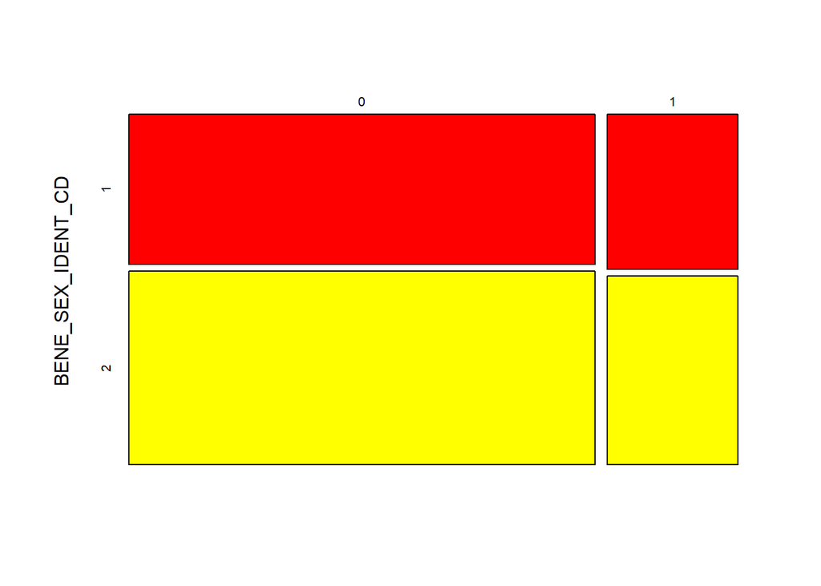

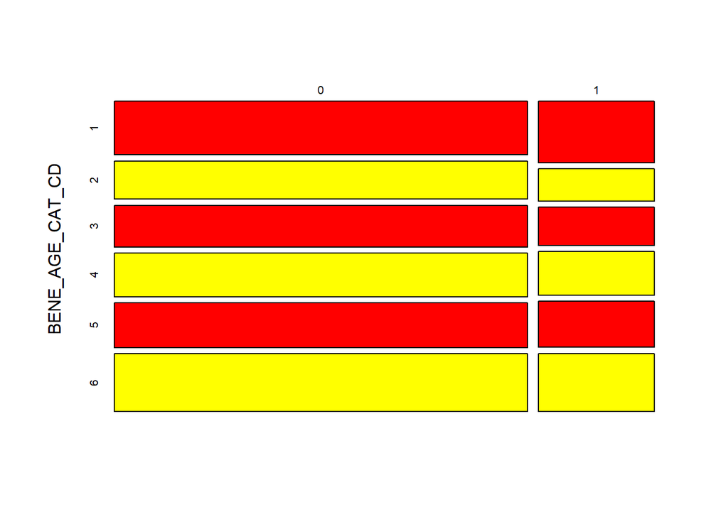

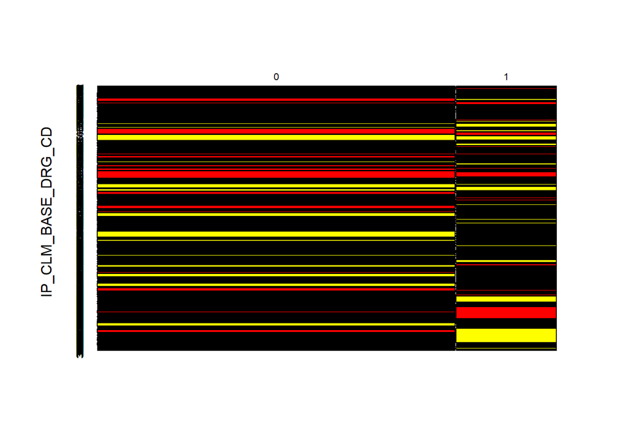

```r
#train model
ip_model_nb <- naive_bayes(IP_long_stay_fl ~ BENE_SEX_IDENT_CD + BENE_AGE_CAT_CD + IP_CLM_BASE_DRG_CD, data = ip_train, laplace = 1)

plot(ip_model_nb)
```

```r
#use model to predict validation data
val_nb1 <- predict(ip_model_nb, ip_validation)  #, type = "prob"
val_nb2 <- cbind(ip_validation, val_nb1)

#comparison of categorization
(comp_nb <- table(val_nb2$IP_long_stay_fl, val_nb2$val_nb1))
```

```
##
##         0     1
##   0 69626  3896
##   1 12770  7853
```

```r
#misclassification %
1- sum(diag(comp_nb))/sum(comp_nb)
```

```
## [1] 0.1770248
```

```r
rm(val_nb2, comp_nb, val_nb1)
```

## K-Nearest Neighbors

```r
#train model
ip_train_knn <- ip_train %>% select(IP_long_stay_fl, BENE_SEX_IDENT_CD, BENE_AGE_CAT_CD,IP_CLM_BASE_DRG_CD) %>% distinct()

ip_validation_knn <- ip_validation %>% select(IP_long_stay_fl, BENE_SEX_IDENT_CD, BENE_AGE_CAT_CD,IP_CLM_BASE_DRG_CD) %>%  distinct()


ip_model_knn <- knn(
                 train = ip_train_knn[-1],
                 test = ip_validation_knn[-1],
                 cl = ip_train_knn$IP_long_stay_fl,
                 k=300,
                 use.all = F
                 )
```

```r
#use model to predict validation data
val_knn1 <-  cbind(ip_validation_knn, ip_model_knn)
val_knn2 <- ip_validation %>% left_join(val_knn1)

#comparison of categorization
(comp_knn <- table(val_knn2$IP_long_stay_fl, val_knn2$ip_model_knn))
```

```
##
##         0     1
##   0 68166  5356
##   1 16512  4111
```

```r
#Misclassification %
1- sum(diag(comp_knn))/sum(comp_knn)
```

```
## [1] 0.23228
```

```r
rm(ip_validation_knn, val_knn1, val_knn2, ip_model_knn, comp_knn)
```

## Logistic Regression

```r
#train model
ip_model_lr <- glm(IP_long_stay_fl ~ BENE_SEX_IDENT_CD + BENE_AGE_CAT_CD + IP_CLM_BASE_DRG_CD,
                   data = ip_train_knn,
                   family = "binomial")
```

```r
#use model to predict validation data
val_lr1a <- predict(ip_model_lr, ip_validation[2:4], type = "response")

val_lr1b <- ifelse(val_lr1a > mean(val_lr1a), 1, 0)
val_lr2 <- cbind(ip_validation, val_lr1b)

#comparison of categorization
(comp_lr <- table(val_lr2$IP_long_stay_fl, val_lr2$val_lr1b))
```

```
##
##         0     1
##   0 30819 42703
##   1  6648 13975
```

```r
#Misclassification %
1- sum(diag(comp_lr))/sum(comp_lr)
```

```
## [1] 0.524202
```

```r
rm(comp_lr, val_lr1a, val_lr1b, val_lr2)
```

## SVM (Support Vector Machines)-Linear Kernal

```r
#train model
ip_train_svm <- ip_train %>% select(IP_long_stay_fl, BENE_SEX_IDENT_CD, BENE_AGE_CAT_CD,IP_CLM_BASE_DRG_CD) %>% distinct()

ip_validation_svm <- ip_validation %>% select(IP_long_stay_fl, BENE_SEX_IDENT_CD, BENE_AGE_CAT_CD,IP_CLM_BASE_DRG_CD) %>%  distinct()


ip_model_svm <- svm(IP_long_stay_fl  ~ BENE_SEX_IDENT_CD + BENE_AGE_CAT_CD + IP_CLM_BASE_DRG_CD,
                    data = ip_train_svm,
                    type= "C-classification",
                    kernel = "linear",
                    scale = FALSE)
ip_model_svm
```

```
##
## Call:
## svm(formula = IP_long_stay_fl ~ BENE_SEX_IDENT_CD + BENE_AGE_CAT_CD +
##     IP_CLM_BASE_DRG_CD, data = ip_train_svm, type = "C-classification",
##     kernel = "linear", scale = FALSE)
##
##
## Parameters:
##    SVM-Type:  C-classification
##  SVM-Kernel:  linear
##        cost:  1
##
## Number of Support Vectors:  4942
```

```r
#use model to predict validation data
val_svm1 <- predict(ip_model_svm, ip_validation_svm[-1])
val_svm1b <-cbind(ip_validation_svm, val_svm1)
val_svm2 <- ip_validation %>% left_join(val_svm1b)

#comparison of categorization
(comp_svm <- table(val_svm2$IP_long_stay_fl, val_svm2$val_svm1))
```

```
##
##         0     1
##   0 73180   342
##   1 19741   882
```

```r
#Misclassification %
1- sum(diag(comp_svm))/sum(comp_svm)
```

```
## [1] 0.2133199
```

```r
rm(ip_model_svm, ip_validation_svm, comp_svm, val_svm1,val_svm1b, val_svm2)
```

## Testing

After the initial run with the training data, we see the following misclassification rate for each approach with the validation data:

- naive bayes: 0.1770248
- k-nearest neighbors: 0.23228
- logistic regression: 0.524202
- SVM: 0.2133199

As naive bayes had the lowest misclassification rate, I used this approach for running the final testing dataset.

```r
#use model to predict test data
val_nb1 <- predict(ip_model_nb, ip_testing)
val_nb2 <- cbind(ip_testing, val_nb1)

#comparison of categorization
(comp_nb <- table(val_nb2$IP_long_stay_fl, val_nb2$val_nb1))
```

```
##
##         0     1
##   0 86930  4972
##   1 15795  9984
```

```r
#Misclassification %
1- sum(diag(comp_nb))/sum(comp_nb)
```

```
## [1] 0.1764686
```

```r
rm(val_nb2, comp_nb, val_nb1)
```

The final misclassification rate for the test data using naive bayes was 17.65%. This was a short preview of several machine learning approaches. Next time I look forward to digging deeper into other metrics to use for evaluating each model’s performance as well as learning more about K-fold Cross-Validation.

[figure not shown]